# EasyVisa Project

### Bivariate Analysis

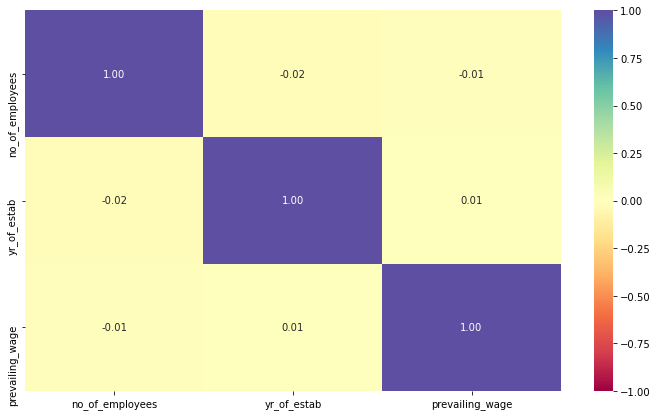

```python
corr_cols = df.select_dtypes(include=np.number).columns.tolist()

plt.figure(figsize=(12, 7))
sns.heatmap(
    df[corr_cols].corr(), annot=True, vmin=-1, vmax=1, fmt=".2f", cmap="Spectral"
)
plt.show()
```

**Observations**

- None of the numeric variables are moderately or highly correlated.

#### Question 1: Those with higher education may want to travel abroad for a well-paid job. Does education play a role in Visa certification?

```python
# compare market segment to bookings

df.groupby("education_of_employee")["case_status"].value_counts()
```

```
education_of_employee  case_status
Bachelor's             Certified      6367
                       Denied         3867
Doctorate              Certified      1912
                       Denied          280
High School            Denied         2256
                       Certified      1164
Master's               Certified      7575
                       Denied         2059
Name: case_status, dtype: int64
```

```
case_status            Certified  Denied    All
education_of_employee
All                        17018    8462  25480
Bachelor's                  6367    3867  10234
High School                 1164    2256   3420
Master's                    7575    2059   9634
Doctorate                   1912     280   2192
------------------------------------------------------------------------------------------------------------------------
```

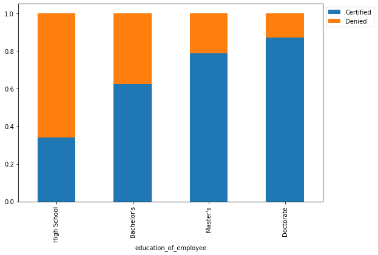

```python
stack(df, 'education_of_employee', 'case_status')
```

**Observations**

- The higher education level an employee has, the larger the ratio of certification approval is.
- Those with high school level education are ~66% denied certification versus ~13% for those with doctorates.
- Overall, around a third of employees are denied certification.

#### Question 2: How does the visa status vary across different continents?

```python
pd.crosstab(df['case_status'], df['continent'])
```

| continent case_status | Africa | Asia | Europe | North America | Oceania | South America |
| --- | --- | --- | --- | --- | --- | --- |
| Certified | 397 | 11012 | 2957 | 2037 | 122 | 493 |
| Denied | 154 | 5849 | 775 | 1255 | 70 | 359 |

```python
pd.crosstab(df['case_status'], df['region_of_employment'])
```

| region_of_employment case_status | Island | Midwest | Northeast | South | West |
| --- | --- | --- | --- | --- | --- |
| Certified | 226 | 3253 | 4526 | 4913 | 4100 |
| Denied | 149 | 1054 | 2669 | 2104 | 2486 |

```
continent    Africa   Asia  Europe  North America  Oceania  South America  \
case_status
All             551  16861    3732           3292      192            852
Certified       397  11012    2957           2037      122            493
Denied          154   5849     775           1255       70            359

continent      All
case_status
All          25480
Certified    17018
Denied        8462
------------------------------------------------------------------------------------------------------------------------
```

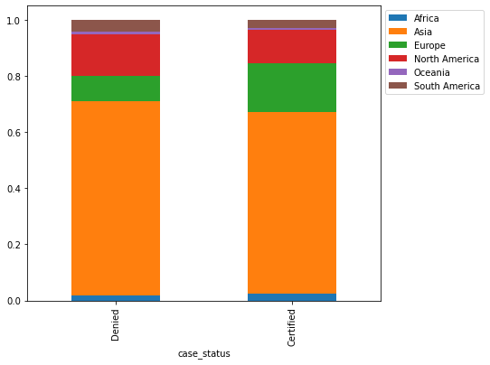

```python
stack(df, 'case_status', 'continent')
```

```
region_of_employment  Island  Midwest  Northeast  South  West    All
case_status
All                      375     4307       7195   7017  6586  25480
Certified                226     3253       4526   4913  4100  17018
Denied                   149     1054       2669   2104  2486   8462
------------------------------------------------------------------------------------------------------------------------
```

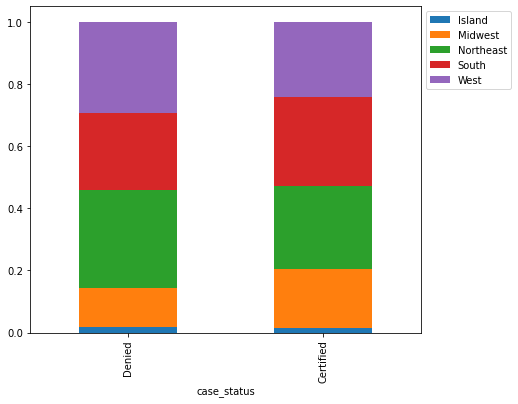

```python
stack(df,'case_status', 'region_of_employment' )
```

**Observations**

#### Question 3: Experienced professionals might look abroad for opportunities to improve their lifestyles and career development. Does work experience influence visa status?

```
case_status         Certified  Denied    All
has_job_experience
All                     17018    8462  25480
N                        5994    4684  10678
Y                       11024    3778  14802
------------------------------------------------------------------------------------------------------------------------
```

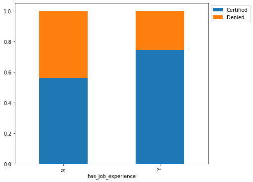

```python
stack(df, 'has_job_experience', 'case_status')
```

```
requires_job_training      N     Y    All
has_job_experience
All                    22525  2955  25480
N                       8988  1690  10678
Y                      13537  1265  14802
------------------------------------------------------------------------------------------------------------------------
```

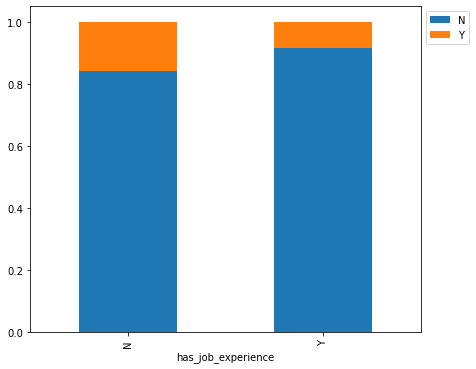

```python
# job experience relationship to requiring job training

stack(df, 'has_job_experience', 'requires_job_training')
```

```python
pd.crosstab(df['has_job_experience'], df['requires_job_training'])
```

| requires_job_training has_job_experience | N | Y |
| --- | --- | --- |
| N | 8988 | 1690 |
| Y | 13537 | 1265 |

**Observations**

- For those with job experience, around 75% are certified, versus 56% of those without job experience.
- Unsurprisingly, those with job experience are in the majority for not requiring job training.

#### Question 4: In the United States, employees are paid at different intervals. Which pay unit is most likely to be certified for a visa?

```
case_status   Certified  Denied    All
unit_of_wage
All               17018    8462  25480
Year              16047    6915  22962
Hour                747    1410   2157
Week                169     103    272
Month                55      34     89
------------------------------------------------------------------------------------------------------------------------
```

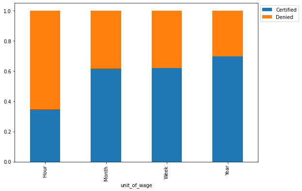

```python
stack(df, 'unit_of_wage', 'case_status')
```

**Observations**

- Those paid on a yearly basis have the highest rate of certification, and hourly basis the lowest.

#### Question 5: The US government has established a prevailing wage to protect local talent and foreign workers. How does the visa status change with the prevailing wage?

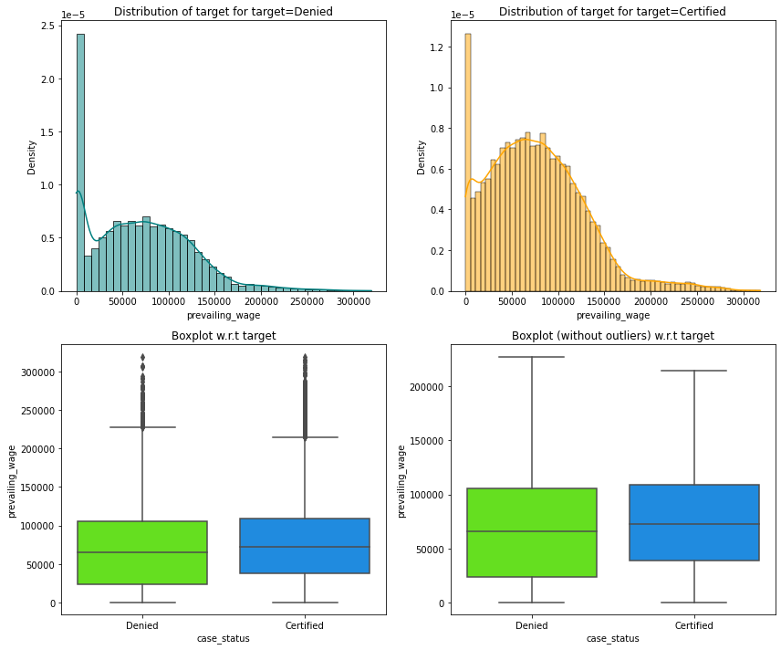

```python
dist_target(df, 'prevailing_wage', 'case_status')
```

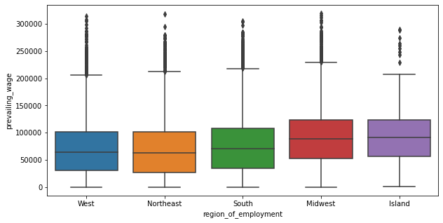

```python
# region of employment vs prevailing wage

plt.figure(figsize=(10, 5))
sns.boxplot(data=df, x="region_of_employment", y="prevailing_wage")
plt.show()
```

## Data Preprocessing

- Missing value treatment (not needed, checked above none missing or duplicates)
- Outlier detection and treatment (if needed)
- Preparing data for modeling
- Any other preprocessing steps (if needed)

### Outlier Detection and Treatment

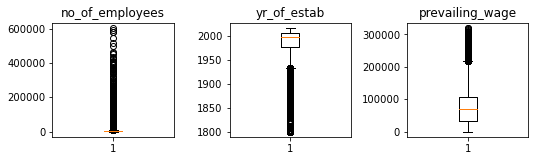

```python
# outlier detection using boxplot

num_cols = df.select_dtypes(include=np.number).columns.tolist()
plt.figure(figsize=(10, 8))

for i, variable in enumerate(num_cols):
    plt.subplot(4, 4, i + 1)
    plt.boxplot(df[variable], whis=1.5)
    plt.tight_layout()
    plt.title(variable)

plt.show()
```

```python
df['yr_of_estab'].describe()
```

```
count    25480.000000
mean      1979.409929
std         42.366929
min       1800.000000
25%       1976.000000
50%       1997.000000
75%       2005.000000
max       2016.000000
Name: yr_of_estab, dtype: float64
```

```python
# many companies established on the lower outlier range year, let's see what some of it looks like

old = df[df["yr_of_estab"] < 1975]

old.head()
```

|  | continent | education_of_employee | has_job_experience | requires_job_training | no_of_employees | yr_of_estab | region_of_employment | prevailing_wage | unit_of_wage | full_time_position | case_status |
| --- | --- | --- | --- | --- | --- | --- | --- | --- | --- | --- | --- |
| 3 | Asia | Bachelor's | N | N | 98 | 1897 | West | 83434.0300 | Year | Y | Denied |
| 7 | North America | Bachelor's | Y | N | 3035 | 1924 | West | 418.2298 | Hour | Y | Denied |
| 12 | Asia | Bachelor's | Y | N | 123876 | 1963 | Northeast | 28663.0500 | Year | Y | Certified |
| 19 | Asia | Doctorate | N | N | 843 | 1972 | Midwest | 79948.1200 | Year | Y | Certified |
| 22 | Asia | Master's | Y | N | 2878 | 1968 | West | 45642.3900 | Year | Y | Certified |

**Observations:**

- There are quite a few outliers in the data, notably in year established and number of employees.
- However, since they are proper values and reflect the distribution of employees, we will not treat them.

## Building bagging and boosting models

- We want to predict which visa will be certified.
- Before we proceed to build a model, we'll have to encode categorical features.
- We'll split the data into train and test to be able to evaluate the model that we build on the train data.

```python
X = df.drop('case_status', axis=1)
y = df["case_status"].apply(lambda x: 1 if x == "Certified" else 0)
```

```python
# create dummy variables

X = pd.get_dummies(X, columns=X.select_dtypes(include=["object", "category"]).columns.tolist(), drop_first=True)

X.head()
```

|  | no_of_employees | yr_of_estab | prevailing_wage | continent_Asia | continent_Europe | continent_North America | continent_Oceania | continent_South America | education_of_employee_Doctorate | education_of_employee_High School | education_of_employee_Master's | has_job_experience_Y | requires_job_training_Y | region_of_employment_Midwest | region_of_employment_Northeast | region_of_employment_South | region_of_employment_West | unit_of_wage_Month | unit_of_wage_Week | unit_of_wage_Year | full_time_position_Y |
| --- | --- | --- | --- | --- | --- | --- | --- | --- | --- | --- | --- | --- | --- | --- | --- | --- | --- | --- | --- | --- | --- |
| 0 | 14513 | 2007 | 592.2029 | 1 | 0 | 0 | 0 | 0 | 0 | 1 | 0 | 0 | 0 | 0 | 0 | 0 | 1 | 0 | 0 | 0 | 1 |
| 1 | 2412 | 2002 | 83425.6500 | 1 | 0 | 0 | 0 | 0 | 0 | 0 | 1 | 1 | 0 | 0 | 1 | 0 | 0 | 0 | 0 | 1 | 1 |
| 2 | 44444 | 2008 | 122996.8600 | 1 | 0 | 0 | 0 | 0 | 0 | 0 | 0 | 0 | 1 | 0 | 0 | 0 | 1 | 0 | 0 | 1 | 1 |
| 3 | 98 | 1897 | 83434.0300 | 1 | 0 | 0 | 0 | 0 | 0 | 0 | 0 | 0 | 0 | 0 | 0 | 0 | 1 | 0 | 0 | 1 | 1 |
| 4 | 1082 | 2005 | 149907.3900 | 0 | 0 | 0 | 0 | 0 | 0 | 0 | 1 | 1 | 0 | 0 | 0 | 1 | 0 | 0 | 0 | 1 | 1 |

```python
# splitting the data in 70:30 ratio for train to test data

X_train, X_test, y_train, y_test = train_test_split(X, y, test_size=0.3, random_state=1)
```

```python
print("Shape of Training set : ", X_train.shape)
print("Shape of test set : ", X_test.shape)
print("Percentage of classes in training set:")
print(y_train.value_counts(normalize=True))
print("Percentage of classes in test set:")
print(y_test.value_counts(normalize=True))
```

```
Shape of Training set :  (17836, 21)
Shape of test set :  (7644, 21)
Percentage of classes in training set:
1    0.663602
0    0.336398
Name: case_status, dtype: float64
Percentage of classes in test set:
1    0.677917
0    0.322083
Name: case_status, dtype: float64
```

### Which case is more important?

- Both the cases are important as:
- If a visa is certified when it had to be denied a wrong employee will get the job position while US citizens will miss the opportunity to work on that position.
- If a visa is denied when it had to be certified the U.S. will lose a suitable human resource that can contribute to the economy.

### How to reduce the losses?

- `F1 Score` can be used a the metric for evaluation of the model, greater the F1 score higher are the chances of minimizing False Negatives and False Positives.
- We will use balanced class weights so that model focuses equally on both classes.

**Let's define a function to provide metric scores on the train and test set and a function to show confusion matrix so that we do not have to use the same code repetitively while evaluating models.**

```python
# defining a function to compute different metrics to check performance of a classification model built using sklearn
def model_performance_classification_sklearn(model, predictors, target):
    """
    Function to compute different metrics to check classification model performance

    model: classifier
    predictors: independent variables
    target: dependent variable
    """

    # predicting using the independent variables
    pred = model.predict(predictors)

    acc = accuracy_score(target, pred)  # to compute Accuracy
    recall = recall_score(target, pred)  # to compute Recall
    precision = precision_score(target, pred)  # to compute Precision
    f1 = f1_score(target, pred)  # to compute F1-score

    # creating a dataframe of metrics
    df_perf = pd.DataFrame(
        {
            "Accuracy": acc,
            "Recall": recall,
            "Precision": precision,
            "F1": f1,
        },
        index=[0],
    )

    return df_perf

def confusion_matrix_sklearn(model, predictors, target):
    """
    To plot the confusion_matrix with percentages

    model: classifier
    predictors: independent variables
    target: dependent variable
    """
    y_pred = model.predict(predictors)
    cm = confusion_matrix(target, y_pred)
    labels = np.asarray(
        [
            ["{0:0.0f}".format(item) + "\n{0:.2%}".format(item / cm.flatten().sum())]
            for item in cm.flatten()
        ]
    ).reshape(2, 2)

    plt.figure(figsize=(6, 4))
    sns.heatmap(cm, annot=labels, fmt="")
    plt.ylabel("True label")
    plt.xlabel("Predicted label")
```

### Decision Tree Model

```
Training performance:
    Accuracy  Recall  Precision   F1
0       1.0     1.0        1.0  1.0
Testing performance:
    Accuracy    Recall  Precision        F1
0   0.66405  0.742184   0.757385  0.749708
```

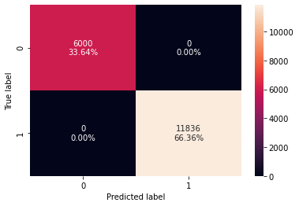

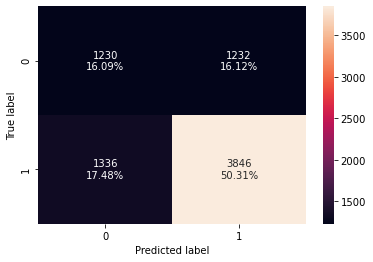

```python
#Fitting the model
d_tree = DecisionTreeClassifier(random_state=1)
d_tree.fit(X_train,y_train)

#Calculating different metrics
d_tree_model_train_perf=model_performance_classification_sklearn(d_tree,X_train,y_train)
print("Training performance:\n",d_tree_model_train_perf)

#Creating confusion matrix
confusion_matrix_sklearn(d_tree,X_train,y_train)

d_tree_model_test_perf=model_performance_classification_sklearn(d_tree,X_test,y_test)
print("Testing performance:\n",d_tree_model_test_perf)

confusion_matrix_sklearn(d_tree,X_test,y_test)
```

- The decision tree is overfitting the training data.
- Let's try hyperparameter tuning and see if the model performance improves.

### Hyperparameter Tuning (Decision Tree)

```python
# Choose the type of classifier.
dtree_estimator = DecisionTreeClassifier(class_weight="balanced", random_state=1)

# Grid of parameters to choose from
parameters = {
    "max_depth": np.arange(10, 30, 5),
    "min_samples_leaf": [3, 5, 7],
    "max_leaf_nodes": [2, 3, 5],
    "min_impurity_decrease": [0.0001, 0.001],
}

# Type of scoring used to compare parameter combinations
scorer = metrics.make_scorer(metrics.f1_score)

# Run the grid search
grid_obj = GridSearchCV(dtree_estimator, parameters, scoring=scorer,n_jobs=-1)
grid_obj = grid_obj.fit(X_train, y_train)

# Set the clf to the best combination of parameters
dtree_estimator = grid_obj.best_estimator_

# Fit the best algorithm to the data.
dtree_estimator.fit(X_train, y_train)
```

```
DecisionTreeClassifier(class_weight='balanced', max_depth=10, max_leaf_nodes=2,
                       min_impurity_decrease=0.0001, min_samples_leaf=3,
                       random_state=1)
```

[output not shown]

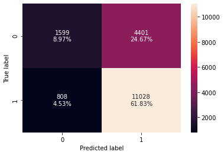

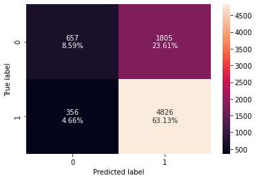

```python
#Calculating different metrics
dtree_estimator_model_train_perf=model_performance_classification_sklearn(d_tree,X_train,y_train)
print("Training performance:\n",dtree_estimator_model_train_perf)

#Creating confusion matrix
confusion_matrix_sklearn(dtree_estimator,X_train,y_train)

dtree_estimator_model_test_perf=model_performance_classification_sklearn(d_tree,X_test,y_test)
print("Testing performance:\n",dtree_estimator_model_test_perf)

#Creating confusion matrix
confusion_matrix_sklearn(dtree_estimator,X_test,y_test)
```

### Random Forest Classifier

```
Training performance:
    Accuracy  Recall  Precision        F1
0  0.999944     1.0   0.999916  0.999958
Testing performance:
    Accuracy    Recall  Precision       F1
0  0.727368  0.833655   0.779502  0.80567
```

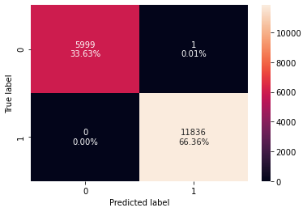

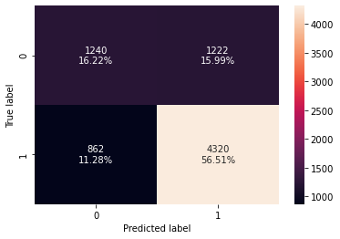

```python
#Fitting the model
rf_estimator = RandomForestClassifier(random_state=1)
rf_estimator.fit(X_train,y_train)

#Calculating different metrics
rf_estimator_model_train_perf=model_performance_classification_sklearn(rf_estimator,X_train,y_train)
print("Training performance:\n",rf_estimator_model_train_perf)

#Creating confusion matrix
confusion_matrix_sklearn(rf_estimator,X_train,y_train)

rf_estimator_model_test_perf=model_performance_classification_sklearn(rf_estimator,X_test,y_test)
print("Testing performance:\n",rf_estimator_model_test_perf)

confusion_matrix_sklearn(rf_estimator,X_test,y_test)
```

- Random forest is giving higher test accuracy, recall, precision, and f1 compared to decision trees.
- Still overfitting the data, let's try hyperparameter tuning and see if the model performance improves.

### Hyperparameter Tuning (Random Forest)

```python
# Choose the type of classifier.
rf_tuned = RandomForestClassifier(random_state=1, oob_score=True, bootstrap=True)

parameters = {
    "max_depth": list(np.arange(5, 15, 5)),
    "max_features": ["sqrt", "log2"],
    "min_samples_split": [3, 5, 7],
    "n_estimators": np.arange(10, 40, 10),
}

# Type of scoring used to compare parameter combinations
acc_scorer = metrics.make_scorer(metrics.f1_score)

# Run the grid search
grid_obj = GridSearchCV(rf_tuned, parameters, scoring=scorer, cv=5,n_jobs=-1)
grid_obj = grid_obj.fit(X_train, y_train)

# Set the clf to the best combination of parameters
rf_tuned = grid_obj.best_estimator_

# Fit the best algorithm to the data.
rf_tuned.fit(X_train, y_train)
```

```
RandomForestClassifier(max_depth=10, max_features='sqrt', min_samples_split=5,
                       n_estimators=30, oob_score=True, random_state=1)
```

```
Training performance:
    Accuracy    Recall  Precision        F1
0  0.770296  0.897432   0.786524  0.838325
Testing performance:
    Accuracy    Recall  Precision        F1
0  0.748038  0.878232   0.778481  0.825354
```

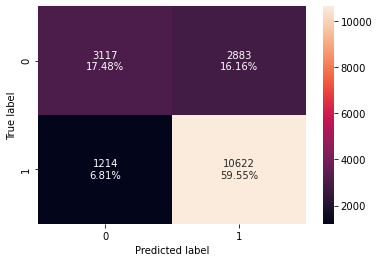

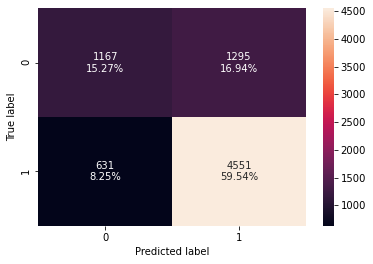

```python
#Calculating different metrics
rf_tuned_model_train_perf=model_performance_classification_sklearn(rf_tuned,X_train,y_train)
print("Training performance:\n",rf_tuned_model_train_perf)
confusion_matrix_sklearn(rf_tuned,X_train,y_train)

rf_tuned_model_test_perf=model_performance_classification_sklearn(rf_tuned,X_test,y_test)
print("Testing performance:\n",rf_tuned_model_test_perf)
confusion_matrix_sklearn(rf_tuned,X_test,y_test)
```

- Model performance has improved and overfitting has reduced.
- Test recall and f1 have increased.

### Bagging Classifier

```
   Accuracy    Recall  Precision        F1
0  0.984526  0.985468   0.991162  0.988307
   Accuracy    Recall  Precision       F1
0  0.696102  0.773061   0.777411  0.77523
```

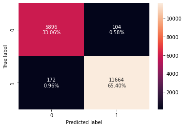

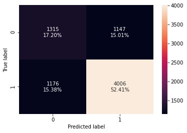

```python
#Fitting the model
bagging_classifier = BaggingClassifier(random_state=1)
bagging_classifier.fit(X_train,y_train)

#Calculating different metrics
bagging_classifier_model_train_perf=model_performance_classification_sklearn(bagging_classifier,X_train,y_train)
print(bagging_classifier_model_train_perf)

#Creating confusion matrix
confusion_matrix_sklearn(bagging_classifier,X_train,y_train)

bagging_classifier_model_test_perf=model_performance_classification_sklearn(bagging_classifier,X_test,y_test)
print(bagging_classifier_model_test_perf)
confusion_matrix_sklearn(bagging_classifier,X_test,y_test)
```

- Let's try hyperparameter tuning and see if the model performance improves.

### Hyperparameter Tuning (Bagging Classifier)

```python
# Choose the type of classifier.
bagging_estimator_tuned = BaggingClassifier(random_state=1)

# Grid of parameters to choose from
parameters = {
    "max_features": [0.7, 0.8, 0.9],
    "n_estimators": [90,100]
}

# Type of scoring used to compare parameter combinations
acc_scorer = metrics.make_scorer(metrics.f1_score)

# Run the grid search
grid_obj = GridSearchCV(bagging_estimator_tuned, parameters, scoring=scorer,cv=5,n_jobs=-1)
grid_obj = grid_obj.fit(X_train, y_train)

# Set the clf to the best combination of parameters
bagging_estimator_tuned = grid_obj.best_estimator_

# Fit the best algorithm to the data.
bagging_estimator_tuned.fit(X_train, y_train)
```

```
BaggingClassifier(max_features=0.7, n_estimators=100, random_state=1)
```

```
   Accuracy  Recall  Precision        F1
0  0.999888     1.0   0.999831  0.999916
   Accuracy    Recall  Precision        F1
0  0.731685  0.894056   0.755175  0.818768
```

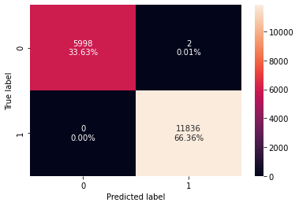

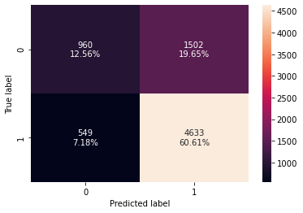

```python
#Calculating different metrics
bagging_estimator_tuned_model_train_perf=model_performance_classification_sklearn(bagging_estimator_tuned,X_train,y_train)
print(bagging_estimator_tuned_model_train_perf)

#Creating confusion matrix
confusion_matrix_sklearn(bagging_estimator_tuned,X_train,y_train)

bagging_estimator_tuned_model_test_perf=model_performance_classification_sklearn(bagging_estimator_tuned,X_test,y_test)
print(bagging_estimator_tuned_model_test_perf)
confusion_matrix_sklearn(bagging_estimator_tuned,X_test,y_test)
```